# Basics

## Histogram

In the probabilistic approach to classification, knowledge of density is all that is required to solve a classification problem. Knowledge of the true density is however rarely given, and one has to estimate the probability density function in feature space. The simplest way to visualize the probability density function in one or two dimensions is by constructing a histogram. The problem with histograms is choosing a suitable number of bins. If the number of bins is very small, useful information will be hidden, whereas if the number of bins is very large, then each bin may not contain enough samples for the histogram to be meaningful.

First, we generate a one dimensional dataset that is normally distributed. We set the number of samples to 1000 and plot the corresponding histogram.

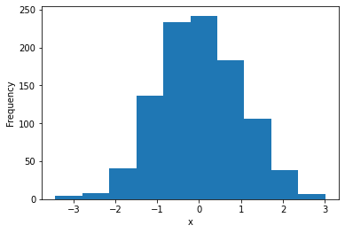

```python
import numpy as np
import matplotlib.pyplot as plt

x = np.random.normal(loc=0,scale=1,size=1000)
plt.hist(x,bins=10,density=False)
plt.xlabel('x')
plt.ylabel('Frequency')
plt.show()
```

## Box Plot

A boxplot provides a way for visualizing data symbolically by summarizing a histogram plot. A boxplot consists of a box with lines extended outward, called the whiskers. The position of the box, whiskers, and other values are based on rank statistics obtained by the following procedure:

1. Data samples are sorted in ascending order.
2. The median is obtained; this is the 50th percentile.
3. The $r^{th}$ percentile is defined as the value at $(r/100) \times n$, where $n$ is the number of samples in the data.

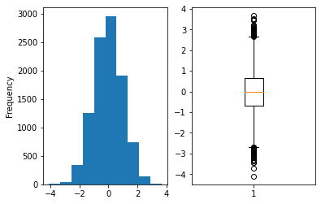

```python
y = np.random.normal(loc=0,scale=1,size=10000)

fig, ax = plt.subplots(1,2)
ax[0].hist(y,density=False)
ax[0].set_ylabel('Frequency')

ax[1].boxplot(y,patch_artist=False,vert=True)
plt.show()
```

## Scatter plot

Scatter plots are useful in visualizing data in the most intuitive manner: simply a plot of objects in feature space.

We load the dataset 'boomerang3D.txt'. It consists of two classes, each with 500 samples in a 3-dimensional feature space. We create a 3D scatter plot and use the labels to specify color.

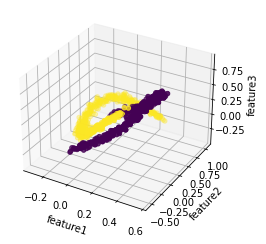

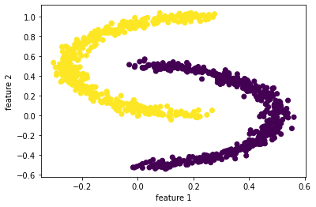

```python
import pandas as pd
path_to_file = '../data/boomerang3D.txt'
df = pd.read_csv(path_to_file, sep=' ')

ax = plt.axes(projection='3d')
ax.scatter(df['feature1'], df['feature2'], df['feature3'], c=df['label'])
ax.set_xlabel('feature1')
ax.set_ylabel('feature2')
ax.set_zlabel('feature3')
plt.show()

plt.scatter(df['feature1'],df['feature2'],c=df['label'])
plt.xlabel('feature 1')
plt.ylabel('feature 2')
plt.show()
```

If the number of features exceeds three, then a single scatter plot is not feasible. In the case of high dimensions, a matrix of pair-wise scatter plots can be generated, showing a scatter plot for every possible pair of features.

We load the dataset 'dataset8D.txt'. It consists of four classes, each with 48 objects in an 8-dimensional feature space. Then, we create a matrix of pair-wise scatter plots.

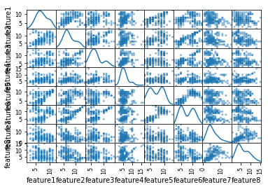

```python
path_to_file = '../data/dataset8D.txt'
data = pd.read_csv(path_to_file, sep=' ')

from pandas.plotting import scatter_matrix
scatter_matrix(data.iloc[:,:-1],diagonal='kde')
plt.show()
```

Next, we compute the covariance matrix of the dataset.

```python
covmat = np.cov(data.iloc[:,:-1],rowvar=False).round(2)
print(covmat)
```

```
[[ 4.64  2.27  1.02  0.41  2.68  1.24 -2.32 -1.18]
 [ 2.27  6.8   2.26  0.26  3.05  4.6  -2.82 -3.29]
 [ 1.02  2.26  6.23  0.77  1.76  3.37 -1.65 -1.96]
 [ 0.41  0.26  0.77  5.09  0.16 -0.45 -0.18  0.54]
 [ 2.68  3.05  1.76  0.16  5.89  5.86 -2.2  -1.98]
 [ 1.24  4.6   3.37 -0.45  5.86  9.35 -2.82 -2.91]
 [-2.32 -2.82 -1.65 -0.18 -2.2  -2.82  9.51  3.9 ]
 [-1.18 -3.29 -1.96  0.54 -1.98 -2.91  3.9   9.58]]
```

We can also compute the correlation matrix. Moreover, we can visualize the correlation matrix as a heatmap.

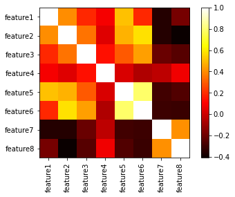

```python
corrmat = np.corrcoef(data.drop('label',axis=1),rowvar=False).round(2)
plt.xticks(ticks=range(len(data.columns)),labels=data.columns,rotation=90)
plt.yticks(ticks=range(len(data.columns)),labels=data.columns)
h = plt.imshow(corrmat,cmap='hot')
plt.colorbar(h)
plt.show()
```

## Central Limit Theorem

The central limit theorem states that the mean (or sum) of a large number of identically and independently distributed samples taken randomly from any distribution with mean $u$ and variance $v$ will follow approximately a Gaussian distribution. As the number of samples $n$ increases, the distribution of the mean approaches exactly the Gaussian distribution with mean $u$ and variance $v/n$.

Since measured quantities in the real world are usually a sum of numerous unobserved random quantities coming from similar distributions, the central limit theorem helps explain why the measured quantity usually ends up following a normal distribution.

We generate a hundred samples randomly from a 1D uniform distribution having values between 0 and 1. Then, we compute the mean and variance of the data. We repeat this 1000 times in a `for` loop and store the mean values. Finally, we plot a histogram of these values.

```
mean of mu: 0.5004148238584399
variance of mu: 0.0008256244744402256
```

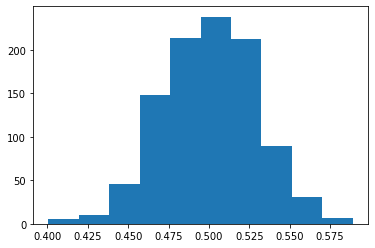

```python
x = np.random.uniform(low=0, high=1, size=100)
x.mean()  # theoretical: (b-a)/2 = 1/2 = 0.5
x.var()  # theoretical: (b-a)^2/12 = 1/12 = 0.08333

mu = []
for i in range(1000):
    x = np.random.uniform(low=0, high=1, size=100)
    mu.append(x.mean())

mu = np.array(mu)
mu.mean()
mu.var()  # theoretical: 0.08333/(n=100)

print(f'mean of mu: {np.mean(mu)}')
print(f'variance of mu: {np.var(mu)}')

plt.hist(mu, density=False)
plt.show()
```

## Parameter Estimation

In data analytics, we often employ training sets and test sets especially for assessing classification. It's often not acceptable to report a value based on a single experiment. In general, when estimating a parameter or reporting a value of any kind, we should repeat the experiment if possible a number of times to obtain a fair estimate and an overview of the spread of the value estimated. We'll illustrate this concept by estimating the mean and variance of a predefined dataset.

Consider a 1D normally distributed dataset with zero mean and unit variance. Let the number of samples be $n$. Then for each case of $n$ = 10, 50, 100, 250, 500, 1000, we'll create a thousand such datasets and estimate for each dataset $i$ the mean value $m(i)$ and variance $v(i)$. Then, we calculate the mean `mean_m`, `mean_v` and standard deviation `sd_m`, `sd_v` of $m$ and $v$. We plot the values as a function of $n$ using the an errorbar plot.

Using error bars (or otherwise confidence intervals) gives an indication of uncertainty which is standard practice when reporting measurements.

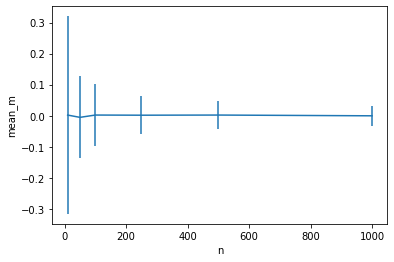

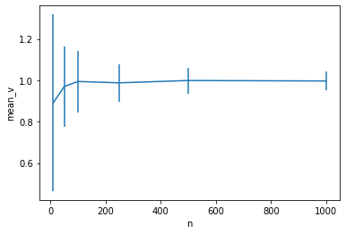

```python
n = [10,50,100,250,500,1000]
mean_m, mean_v, sd_m, sd_v = ([] for i in range(4));

for i in n: #range(len(n)):
    m,v = [],[]
    for j in range(1000):
        #print(j)
        a = np.random.normal(loc=0,scale=1,size=i)
        m.append(a.mean())
        v.append(a.var())
    mean_m.append(np.mean(m))
    sd_m.append(np.std(m))
    mean_v.append(np.mean(v))
    sd_v.append(np.std(v))

plt.errorbar(n, mean_m, sd_m)
plt.xlabel('n')
plt.ylabel('mean_m')
plt.show()

plt.errorbar(n, mean_v, sd_v)
plt.xlabel('n')
plt.ylabel('mean_v')
plt.show()
```

## Data Sphering

We generate a 2D normal distribution with zero mean and covariance matrix: $\Sigma = I$. Let the number of samples be 1000. We compute the covariance matrix and find the eigenvalues and eigenvectors. The eigenvectors are stored as columns.

```python
mean = np.zeros(2)
cov = np.eye(2)
x = np.random.multivariate_normal(mean=mean, cov=cov, size=1000)
S = np.cov(x, rowvar=False)
w, v = np.linalg.eig(S)
print(v)
```

```
[[-0.79311661 -0.60906982]
 [ 0.60906982 -0.79311661]]
```

We repeat the procedure with $\Sigma = \begin{pmatrix} 3 & 0 \\ 0 & 1 \end{pmatrix}$. We also create a 2D scatter plot of the data and plot the eigenvectors in the same figure. Finally, we plot the eigenvectors scaled by the square root of their corresponding eigenvalues.

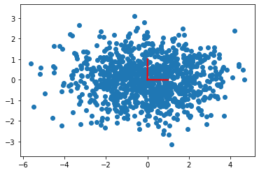

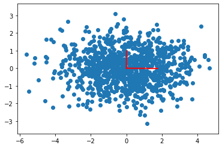

```python
z = np.random.multivariate_normal([0,0],[[3,0],[0,1]],1000)
C = np.cov(z.T)
w, v = np.linalg.eig(C)

plt.scatter(z[:,0],z[:,1])
plt.plot([0,v[0,0]],[0,v[1,0]],color='red',linewidth=2)
plt.plot([0,v[0,1]],[0,v[1,1]],color='red',linewidth=2)
plt.axis('equal')
plt.show()

plt.scatter(z[:,0],z[:,1])
plt.plot(np.sqrt(w[0])*np.array([0,v[0,0]]),np.sqrt(w[0])*np.array([0,v[1,0]]),color='red',linewidth=2)
plt.plot(np.sqrt(w[1])*np.array([0,v[0,1]]),np.sqrt(w[1])*np.array([0,v[1,1]]),color='red',linewidth=2)
plt.axis('equal')
plt.show()
```

Now, we change $\Sigma$ to $\begin{pmatrix} 3 & -2 \\ -2 & 2 \end{pmatrix}$, and once again we create a scatter plot with a plot of the eigenvectors scaled by the square root of their corresponding eigenvalues.

**q = z.dot(e).dot(np.linalg.inv(np.sqrt(D)))**

We'll create two scatter plots superimposed, one for the original data and the other for the sphered data.

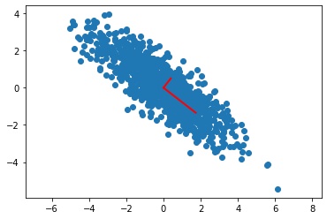

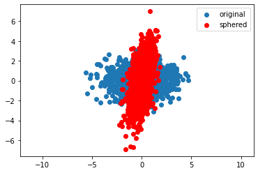

```python
x = np.random.multivariate_normal(mean=[0,0], cov=[[3,-2],[-2,2]], size=1000)
S = np.cov(x.T)
w, v = np.linalg.eig(S)

plt.scatter(x[:,0], x[:,1])
plt.plot(np.sqrt(w[0])*np.array([0, v[0,0]]), np.sqrt(w[0])*np.array([0, v[1,0]]), color='red', linewidth=2)
plt.plot(np.sqrt(w[1])*np.array([0, v[0,1]]), np.sqrt(w[1])*np.array([0, v[1,1]]), color='red', linewidth=2)
plt.axis('equal')
plt.show()

D = np.diag(w)
q = z.dot(v).dot(np.linalg.inv(np.sqrt(D)))

plt.scatter(z[:,0],z[:,1])
plt.scatter(q[:,0],q[:,1],color='red')
plt.axis('equal')
plt.legend(['original','sphered'])
plt.show()
```

## Non-Parametric Density Estimation

### Parzen Density Estimation

We load the data from the file 'dataset1D.txt'. The dataset $a$ consists of two classes with 20 objects in each (labels aren't provided). The samples are drawn from a 1D normal distribution. We'll use a default Gaussian kernel to estimate the density over the given dataset, while plotting the 1D scatter plot of the data.

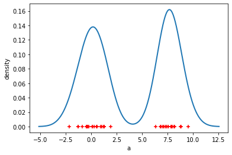

```python
from sklearn.neighbors import KernelDensity

path_to_file = '../data/dataset1D.txt'
data = pd.read_csv(path_to_file, sep=' ')
a = data['a']

model = KernelDensity(kernel='gaussian',bandwidth=1)
model.fit(np.array(a).reshape(-1,1))
x = np.linspace(a.min()-3,a.max()+3,1000).reshape(-1,1)
log_dens = model.score_samples(x)
y = np.exp(log_dens)

plt.plot(x,y,linewidth=2)
plt.scatter(a,np.zeros(len(a)),marker='+',color='red')
plt.xlabel('a')
plt.ylabel('density')
plt.show()
```

We can try different bandwidth values for the kernel.

To evaluate the fit of a density model to the actual data, an error measure is required. In this case, we can use the log-likelihood defined by:

$LL(x) = ln \left( \prod_i \widehat{p}(x_i) \right) = \sum_i ln(\widehat{p}(x_i))$

If the model fits well, then the log-likelihood should be high. Different kernel widths, $h$, result in different models. Thus, using the log-likelihood, we can choose an optimal kernel width, $h$, that corresponds to a maximum log-likelihood measure. Notably, the log-likelihood must be evaluated on an independent test set. That is, it isn't acceptable to evaluate the log-likelihood using the same training set on which the probability density function was fitted as this would lead to a biased (optimistic) evaluation.

The file 'dataset1D.txt' contains a training set `trn` and a test set `tst` of equal size, randomly sampled from the original distribution that `a` was sampled from. We'll estimate the Parzen density using the training set and calculate the log-likelihood on the test set for kernel widths $h = [0.1, 0.25, 0.5, 1, 1.5, 2, 3, 4, 5]$.

Then, we plot the log-likelihood curve as a function of $h$.

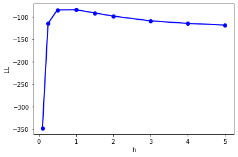

```
1
```

```python
h = [0.1,0.25,0.5,1,1.5,2,3,4,5]
ll = []
for i in h:
    model = KernelDensity(bandwidth=i)
    model.fit(np.array(data['trn']).reshape(-1,1))
    log_dens = model.score_samples(np.array(data['tst']).reshape(-1,1))
    y = np.exp(log_dens)
    ll.append(np.log(y).sum())

plt.plot(h,ll,color='blue',linewidth=2)
plt.scatter(h,ll,color='blue')
plt.xlabel('h')
plt.ylabel('LL')
plt.show()

h[np.array(ll).argmax()]
```

### Nearest Neighbor Density Estimation

We'll write our own function, **knn()**, that implements the k-nearest neighbor density estimation method for the 1D case. The function should take in three arguments, a training set `a`, a test set `b` at which to evaluate the density, and a value for `k`. The output should be the density values estimated over `b`.

We test the function on 'dataset1D.txt'. We'll use the dataset $a$ for training, and a grid over the range of `a` for testing.

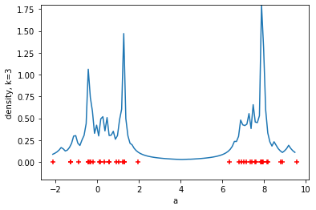

```python
def knn(trn,tst,k):
    from scipy.spatial import distance
    testDistMat = distance.cdist(tst,trn,'euclidean')
    n = len(trn)
    p = []
    for i in range(testDistMat.shape[0]):
        knndist = np.sort(testDistMat[i,:])[k-1]
        p.append((k/n)/knndist)
    return p

path_to_file = '../data/dataset1D.txt'
data = pd.read_csv(path_to_file, sep=' ')

trn = np.array(data['a']).reshape(-1,1)
tst = np.arange(trn.min(),trn.max(),0.1).reshape(-1,1)
k = 3

p = knn(trn,tst,k)
plt.plot(tst,p)
plt.xlabel('a')
plt.ylabel('density, k=3')
plt.ylim([-0.2,max(p)])
plt.scatter(trn,np.zeros(len(trn)),marker='+',color='red')
plt.show()
```